# Univariate Viz — Exercises

**ImportantICA Instructions**

Before starting, review the [ICA Instructions ⭐](https://hash-mac.github.io/ds112site-f26/activities/ica-instructions.html) for details on pair programming and activity procedures.

## Setup

Load the data first.

```r
# Import data
hikes <- read.csv("https://mac-stat.github.io/data/high_peaks.csv")
```

## Exercise 1: Research Questions

Let’s dig into the `hikes` data, starting with the `elevation` and difficulty `ratings` of the hikes:

```r
head(hikes)
```

```
             peak elevation difficulty ascent length time    rating
1     Mt. Marcy        5344          5   3166   14.8 10.0  moderate
2 Algonquin Peak       5114          5   2936    9.6  9.0  moderate
3   Mt. Haystack       4960          7   3570   17.8 12.0 difficult
4   Mt. Skylight       4926          7   4265   17.9 15.0 difficult
5 Whiteface Mtn.       4867          4   2535   10.4  8.5      easy
6       Dix Mtn.       4857          5   2800   13.2 10.0  moderate
```

1. What features would we like a visualization of the *categorical* difficulty `rating` variable to capture? How many types of ratings. Separate into groups based on rating.
2. What about a visualization of the *quantitative* `elevation` variable? Show elevations in a scatter plot. See relative heights.

## Exercise 2: Load tidyverse

We’ll address the above questions using `ggplot` tools. Try running the following chunk and simply take note of the error message – this is one you’ll get a lot!

```r
# Use the ggplot function
#ggplot(hikes, aes(x = rating))
```

In order to use `ggplot` tools, we have to first *load* the `tidyverse` package in which they live. We’ve *installed* the package but we need to tell R when we want to *use* it. Run the chunk below to load the library. You’ll need to do this within any .qmd file that uses `ggplot()`.

```r
# Load the package
library(tidyverse)
```

## Exercise 3: Bar Chart of Ratings - Part 1

All of these questions can be answered with: (1) a **bar chart**; of (2) the *categorical* data recorded in the `rating` column. First, set up the plotting **frame**:

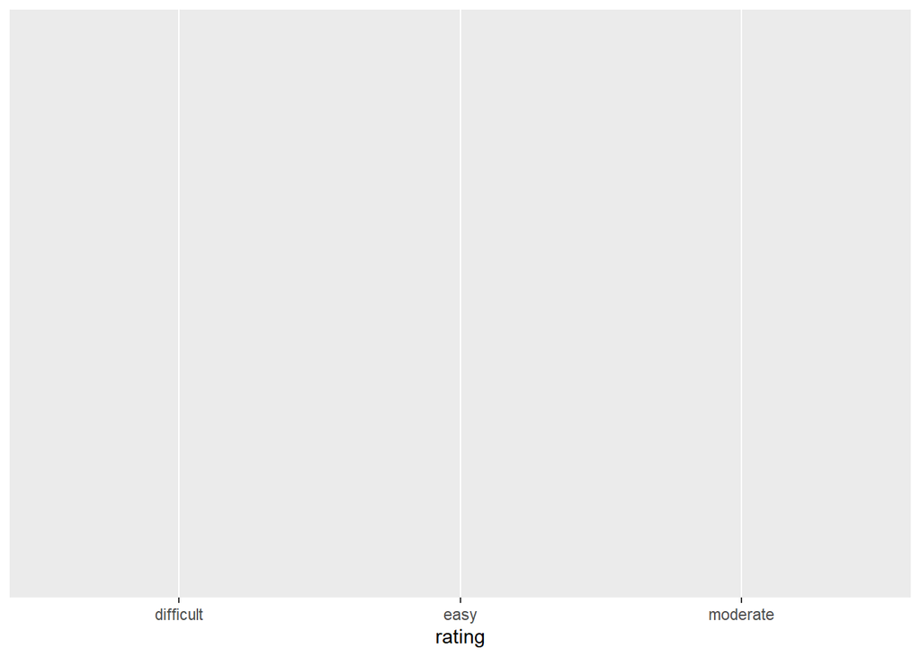

```r
ggplot(hikes, aes(x = rating))
```

Think about:

- What did this do? What do you observe? Made the frame of the plot
- What, in general, is the first argument of the `ggplot()` function? It is the data set we are using
- What is the purpose of writing `x = rating`? Distinguish x axis variable
- What do you think `aes` stands for?!? Aestetic

## Exercise 4: Bar Chart of Ratings - Part 2

Now let’s add a **geometric layer** to the frame / canvas, and start customizing the plot’s **theme**. To this end, try each chunk below, *one by one*. In each chunk, make a comment about how both the code and the corresponding plot both changed.

NOTE:

- Pay attention to the general code properties and structure, not memorization.
- Not all of these are “good” plots. We’re just exploring `ggplot`.

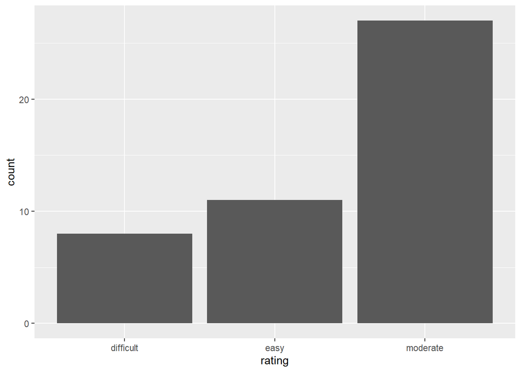

```r
# COMMENT on the change in the code and the corresponding change in the plot
ggplot(hikes, aes(x = rating)) +
  geom_bar()
```

Added the type of plot. Bar plot in this case.

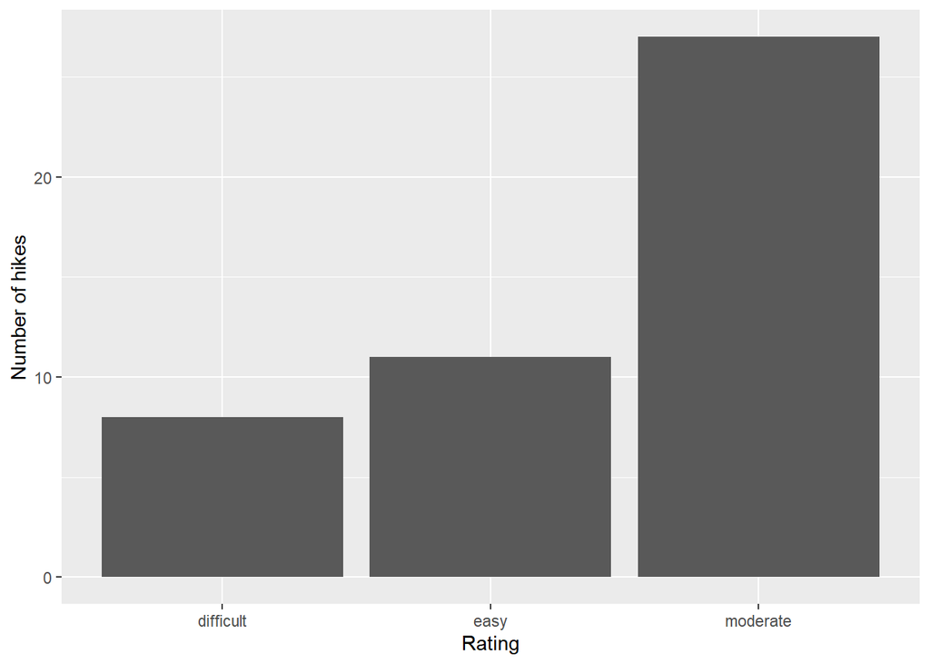

```r
# COMMENT on the change in the code and the corresponding change in the plot
ggplot(hikes, aes(x = rating)) +
  geom_bar() +
  labs(x = "Rating", y = "Number of hikes")
```

Labeled the axes

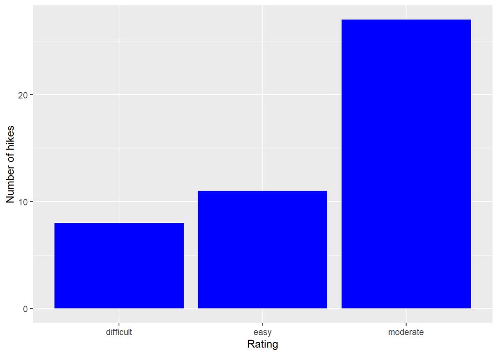

```r
# COMMENT on the change in the code and the corresponding change in the plot
ggplot(hikes, aes(x = rating)) +
  geom_bar(fill = "blue") +
  labs(x = "Rating", y = "Number of hikes")
```

Made the bars blue

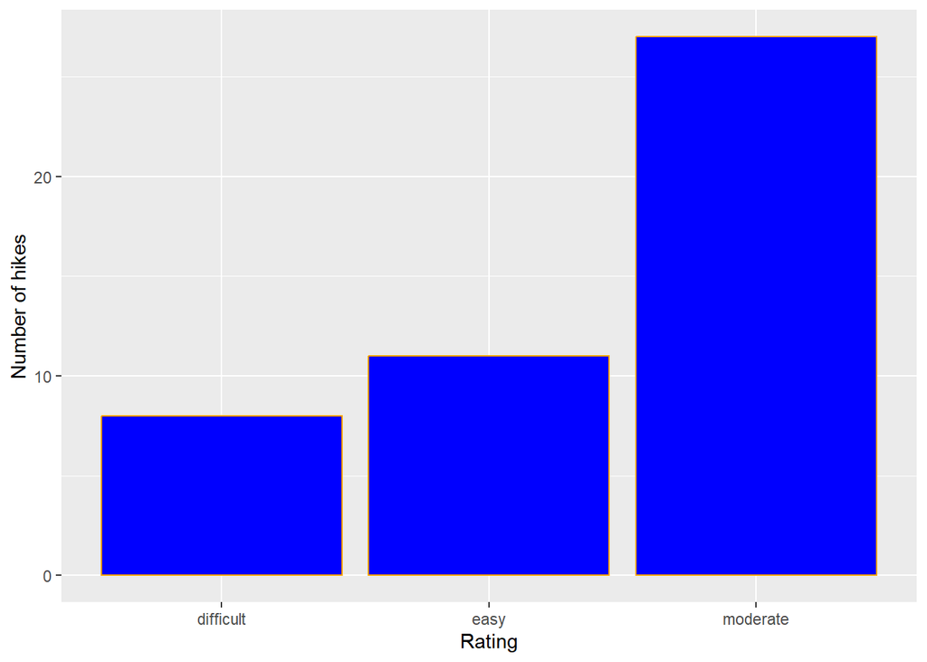

```r
# COMMENT on the change in the code and the corresponding change in the plot
ggplot(hikes, aes(x = rating)) +
  geom_bar(color = "orange", fill = "blue") +
  labs(x = "Rating", y = "Number of hikes")
```

Made the outline orange

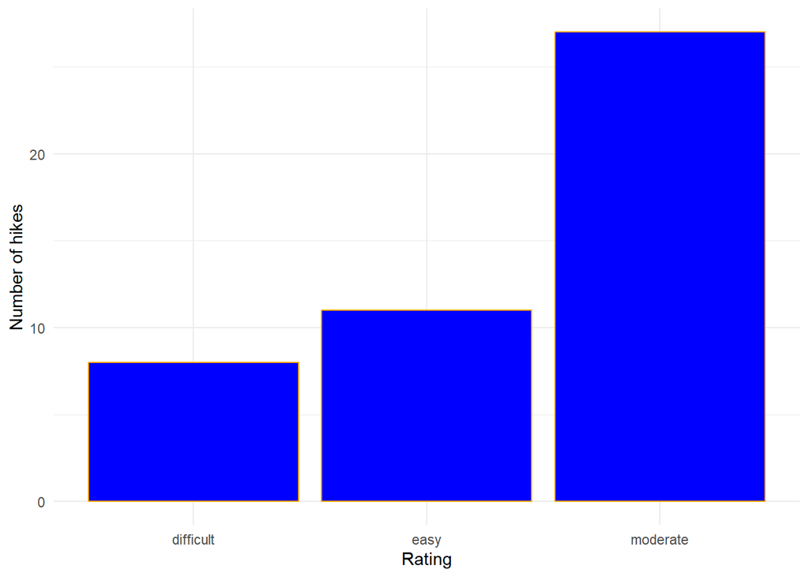

```r
# COMMENT on the change in the code and the corresponding change in the plot
ggplot(hikes, aes(x = rating)) +
  geom_bar(color = "orange", fill = "blue")  +
  labs(x = "Rating", y = "Number of hikes") +
  theme_minimal()
```

Made it a minimal background. Just white with ticks.

## Exercise 5: Bar Chart Follow-up

#### Part a

Reflect on the `ggplot()` code.

- What’s the purpose of the `+`? When do we use it? Add another layer of the chart.
- We added the bars using `geom_bar()`? Why “geom”? geom means shape? Shape of the chart.
- What does `labs()` stand for? Labels
- What’s the difference between `color` and `fill`? Color is the outline, fill is the filling

#### Part b

In general, bar charts allow us to examine the following properties of a *categorical* variable:

- **observed categories**: What categories did we observe? rating
- **variability between categories**: Are observations evenly spread out among the categories, or are some categories more common than others? some are more common than others

We must then *translate* this information into the *context* of our analysis, here hikes in the Adirondacks. Summarize below what you learned from the bar chart, in context. There are more moderate hikes in the Adirondacks than either easy or difficult hikes.

#### Part c

Is there anything you don’t like about this barplot? For example: check out the x-axis again. Rating is not clarifying. Difficulty to hike would be a better label.

## Exercise 6: Sad Bar Chart

Let’s now consider some research questions related to the *quantitative* `elevation` variable:

1. Among the hikes, what’s the *range* of elevation and how are the hikes *distributed* within this range (eg, evenly, in clumps, “normally”)?
2. What’s a *typical* elevation?
3. Are there any *outliers*, ie, hikes that have unusually high or low elevations?

Here:

- Construct a **bar chart** of the *quantitative* `elevation` variable.
- Explain why this might *not* be an effective visualization for this and other quantitative variables. (What questions does / doesn’t it help answer?)

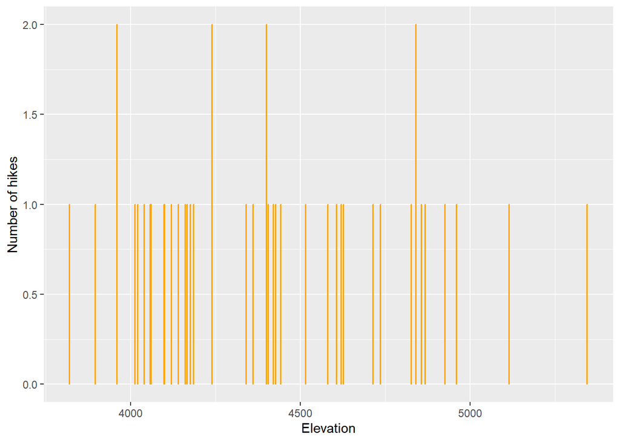

```r
# write your code here
ggplot(hikes, aes(x = elevation)) +
  geom_bar(color = "orange", fill = "blue") +
  labs(x = "Elevation", y = "Number of hikes")
```

## Exercise 7: A Histogram of Elevation

Quantitative variables require different viz than categorical variables. Especially when there are many possible outcomes of the quantitative variable. It’s typically insufficient to simply count up the number of times we’ve observed a particular outcome as the bar graph did above. It gives us a sense of ranges and typical outcomes, but not a good sense of how the observations are distributed across this range. We’ll explore two methods for graphing quantitative variables: **histograms** and **density plots**.

**Histograms** are constructed by (1) dividing up the observed range of the variable into ‘bins’ of equal width; and (2) counting up the number of cases that fall into each bin. Check out the example below:

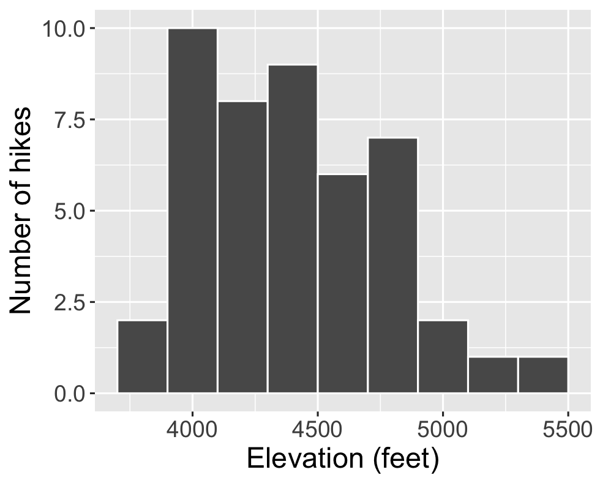

#### Part a

Let’s dig into some details.

- How many hikes have an elevation between 4500 and 4700 feet?’ 6 hikes
- How many total hikes have an elevation of at least 5100 feet? 2 hikes

#### Part b

Now the bigger picture. In general, histograms allow us to examine the following properties of a *quantitative* variable:

- **typical outcome:** Where’s the center of the data points? What’s typical?
- **variability & range:** How spread out are the outcomes? What are the max and min outcomes?
- **shape:** How are values distributed along the observed range? Is the distribution symmetric, right-skewed, left-skewed, bi-modal, or uniform (flat)?
- **outliers:** Are there any outliers, ie, outcomes that are unusually large/small?

We must then *translate* this information into the *context* of our analysis, here hikes in the Adirondacks. Addressing each of the features in the above list, summarize below what you learned from the histogram, in context.

```r
hikes |>
  summarize(mean(elevation), median(elevation), min(elevation), max(elevation))
```

```
  mean(elevation) median(elevation) min(elevation) max(elevation)
1        4405.283            4380.5           3820           5344
```

The mean and median values are given. Both show that elevations are typically are around 4400 feet. The max and min are shown. The distribution is skewed slightly to the right, with fewer higher elevation peaks. There are no outliers.

## Exercise 8: Building Histograms - Part 1

2-MINUTE CHALLENGE: Thinking of the bar chart code, try to *intuit* what line you can tack on to the below frame of `elevation` to add a histogram layer. Don’t forget a `+`. If it doesn’t come to you within 2 minutes, *no problem* – all will be revealed in the next exercise.

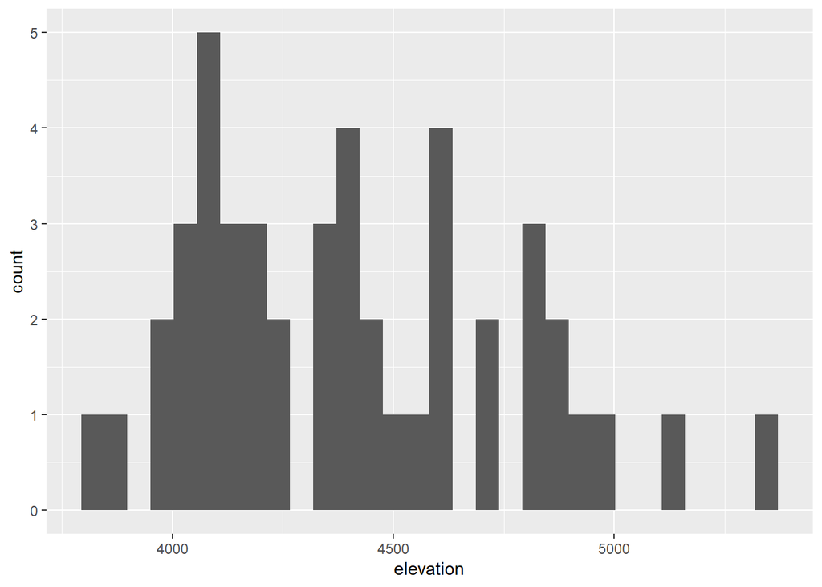

```r
ggplot(hikes, aes(x = elevation))+
  geom_histogram()
```

## Exercise 9: Building Histograms - Part 2

Let’s build some histograms. Try each chunk below, *one by one*. In each chunk, make a comment about how both the code and the corresponding plot both changed.

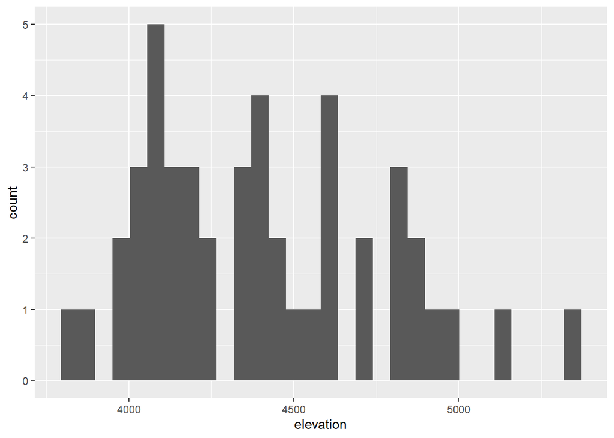

```r
# COMMENT on the change in the code and the corresponding change in the plot
ggplot(hikes, aes(x = elevation)) +
  geom_histogram()
```

makes plot

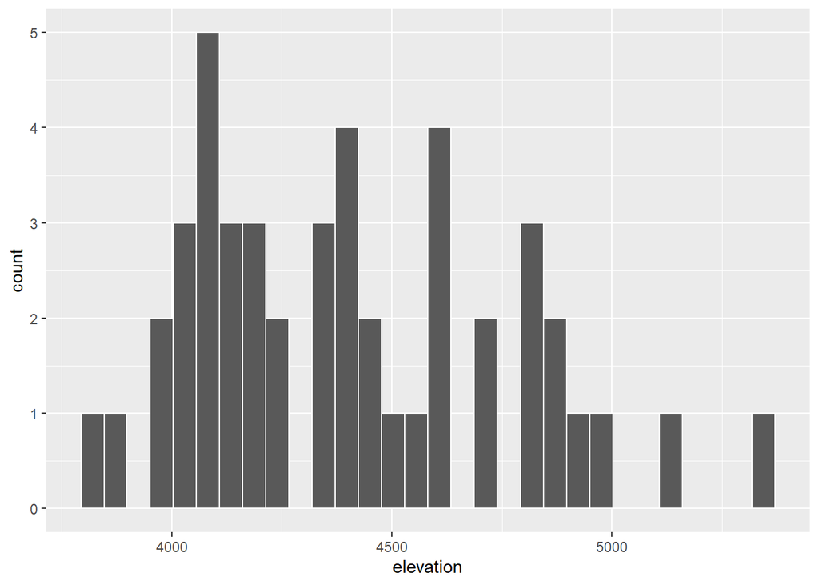

```r
# COMMENT on the change in the code and the corresponding change in the plot
ggplot(hikes, aes(x = elevation)) +
  geom_histogram(color = "white")
```

makes outline color white

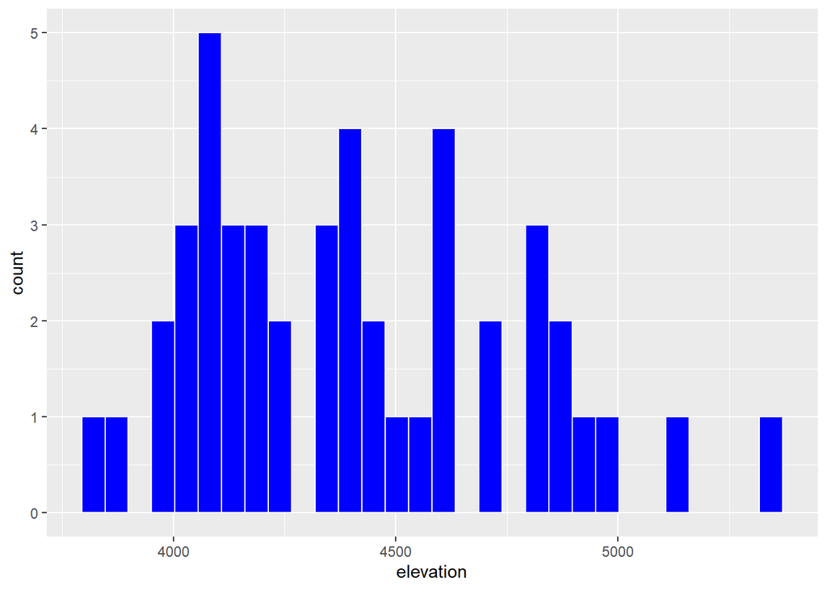

```r
# COMMENT on the change in the code and the corresponding change in the plot
ggplot(hikes, aes(x = elevation)) +
  geom_histogram(color = "white", fill = "blue")
```

makes fill blue

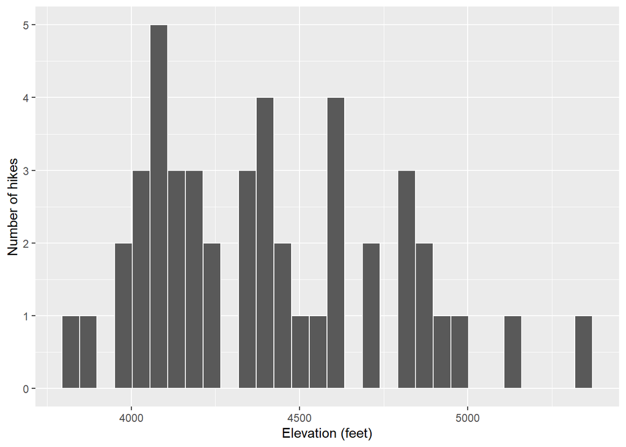

```r
# COMMENT on the change in the code and the corresponding change in the plot
ggplot(hikes, aes(x = elevation)) +
  geom_histogram(color = "white") +
  labs(x = "Elevation (feet)", y = "Number of hikes")
```

makes outline white, adds better labels to axes

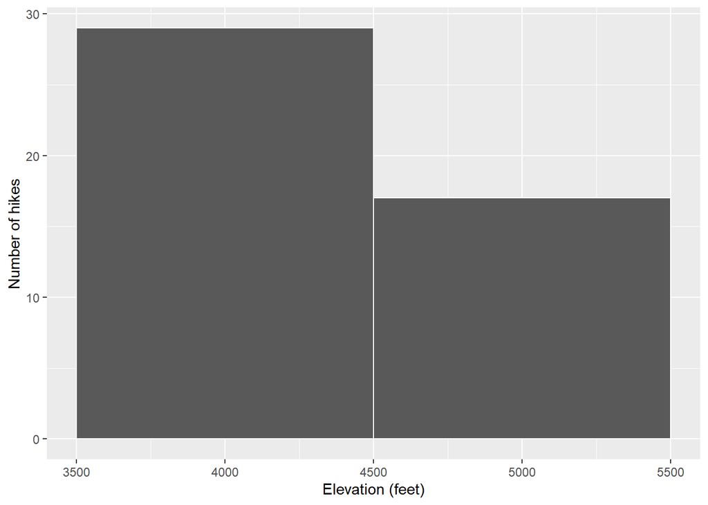

```r
# COMMENT on the change in the code and the corresponding change in the plot
ggplot(hikes, aes(x = elevation)) +
  geom_histogram(color = "white", binwidth = 1000) +
  labs(x = "Elevation (feet)", y = "Number of hikes")
```

changes bin width to make bins larger

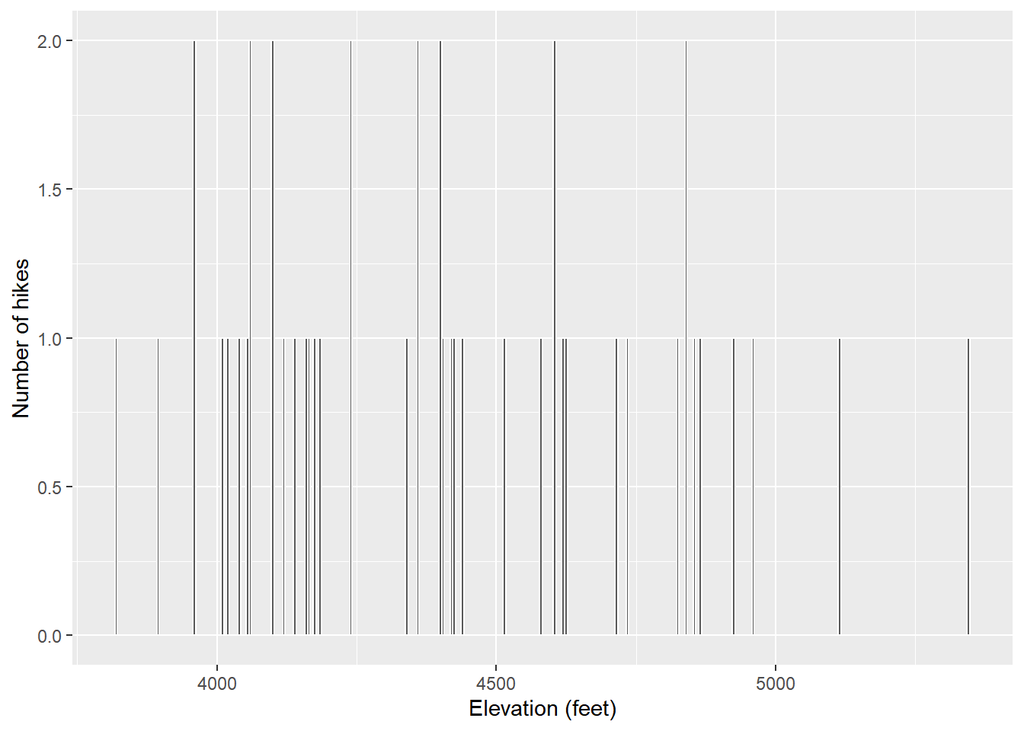

```r
# COMMENT on the change in the code and the corresponding change in the plot
ggplot(hikes, aes(x = elevation)) +
  geom_histogram(color = "white", binwidth = 5) +
  labs(x = "Elevation (feet)", y = "Number of hikes")
```

changes bin width to make bins smaller

```r
# COMMENT on the change in the code and the corresponding change in the plot
ggplot(hikes, aes(x = elevation)) +
  geom_histogram(color = "white", binwidth = 200) +
  labs(x = "Elevation (feet)", y = "Number of hikes")
```

[output not shown]

makes bin width reasonable

## Exercise 10: Histogram Follow-up

- What function added the histogram layer / geometry? geom_histogram()
- What’s the difference between `color` and `fill`? color changes the outline color, fill changes the fill color
- Why does adding `color = "white"` improve the visualization? outlines the bins to distinguish their edges
- What did `binwidth` do? changed the bin width
- Why does the histogram become ineffective if the `binwidth` is too big (eg, 1000 feet)? all the peaks are lumped together into a few bins
- Why does the histogram become ineffective if the `binwidth` is too small (eg, 5 feet)? all the peaks are separated, we dont put peaks that are similar elevations together

## Exercise 11: Density Plots

**Density plots** are essentially smooth versions of the histogram. Instead of sorting observations into discrete bins, the “density” of observations is calculated across the entire range of outcomes. The greater the number of observations, the greater the density! The density is then scaled so that the area under the density curve **always equals 1** and the area under any fraction of the curve represents the fraction of cases that lie in that range.

Check out a density plot of elevation. Notice that the y-axis (density) has no contextual interpretation – it’s a relative measure. The *higher* the density, the more *common* are elevations in that range.

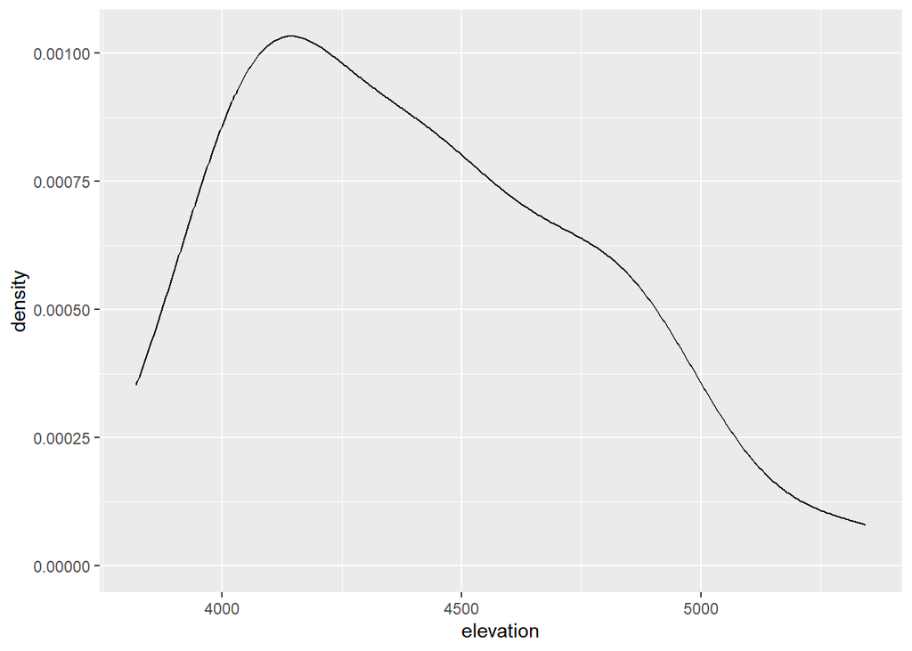

```r
ggplot(hikes, aes(x = elevation)) +
  geom_density()
```

**Questions**

- INTUITION CHECK: Before tweaking the code and thinking back to `geom_bar()` and `geom_histogram()`, how do you *anticipate* the following code will change the plot?
  - `geom_density(color = "blue")` Makes the curve blue
  - `geom_density(fill = "orange")` makes the area under the curve orange
- TRY IT! Test out those lines in the chunk below. Was your intuition correct?

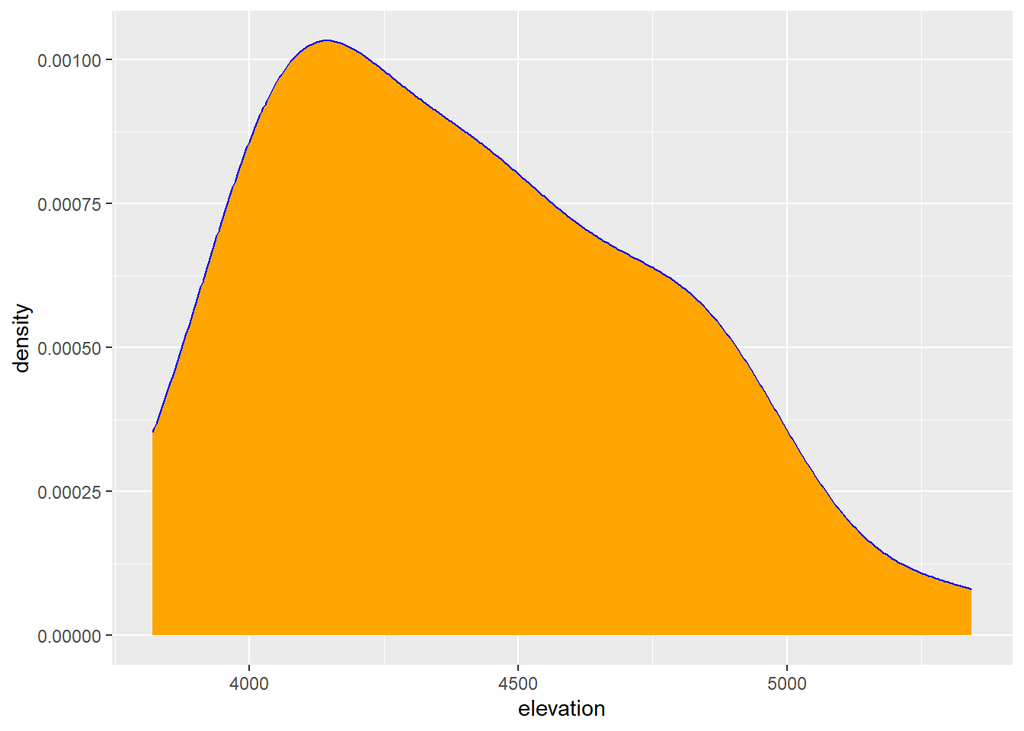

```r
# Write your code here
ggplot(hikes, aes(x = elevation)) +
  geom_density(color = "blue", fill = "orange")
```

- Examine the density plot. How does it compare to the histogram? What does it tell you about the *typical* elevation, *variability / range* in elevations, and *shape* of the distribution of *elevations* within this range?

It is a similar shape to the histogram, with smoother curves. It shows where the most peaks are, but does not use counts, it uses the percentage of the total number of peaks each elevation contributes. We can see the skew more clearly. It tails off to the right. We can see the minimum and maximum elevations.